# Stoat control does not lead to larger mouse eruptions in New Zealand beech forest

### Prediction C

*Stoat control did not increase mouse populations as food becomes avaliable.*

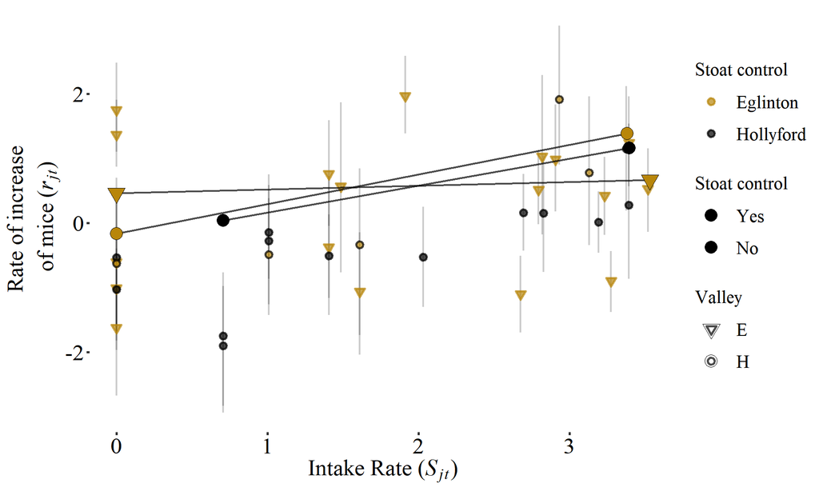

### Prediction D

*Stoat control did not hasten the decline from peak abundance.*

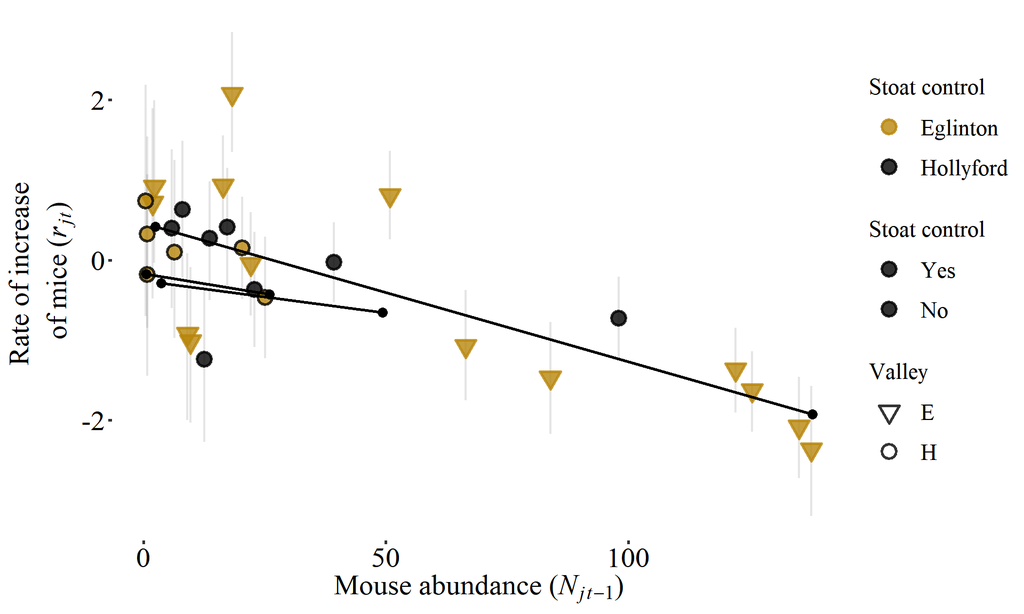

### Prediction E

*Does the presence of rats impact the population dynamics of mice at each of the seasons tested in Predictions A-D.*

We found that rat numbers $R_{j,t}$ had the smallest overall effect on mice dynamics ($\mu(\beta_3 | All \space Seasons)= 0.007$) and was the most variable parameter in our community model ($CV_{rats} = 5.74$). We recorded the highest number of rats in February and May, at the same times of high mouse abundance (Figure 3.3).

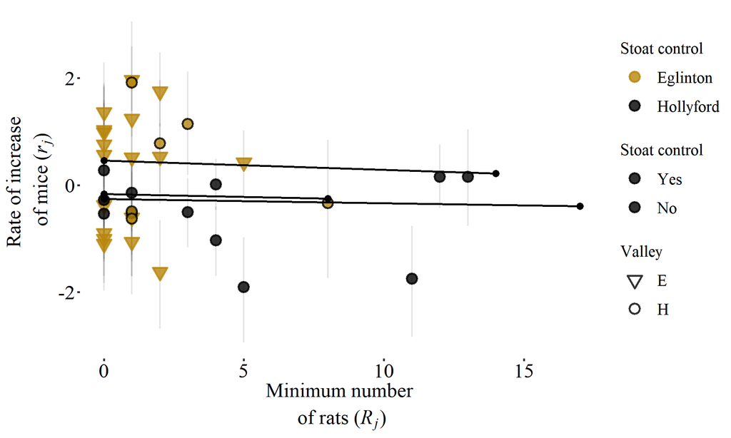

The relationship between rats and mice was examined by comparing the estimated differences between treatments (Figure 8; lines represent mean relationships in the three treatment groups). We also statistically testing the difference between each different treatment and found no differences across all parameters (Figure 9).

[output not shown]

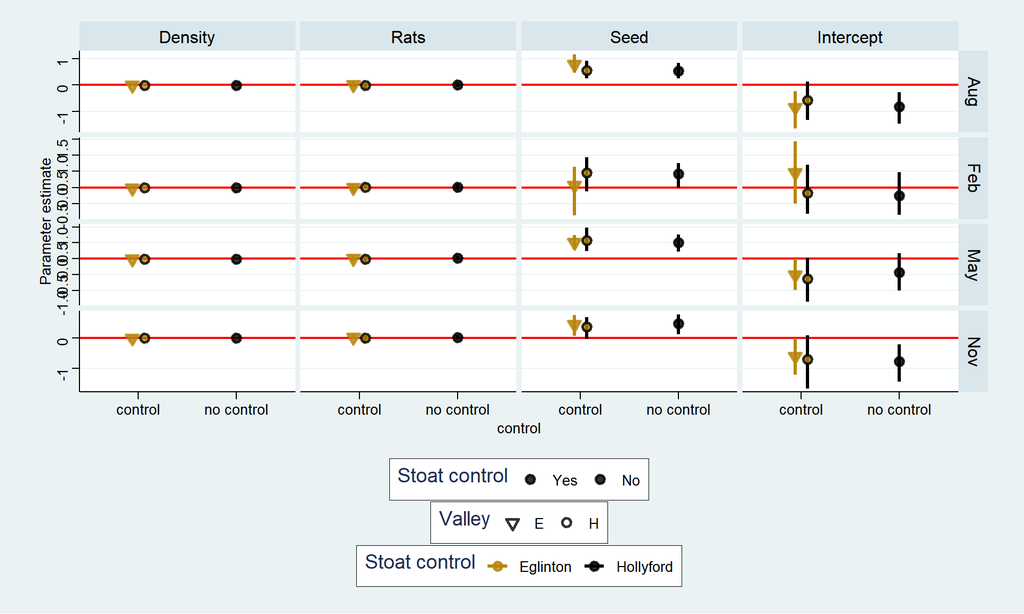

**Figure 9:** *Differences in estimates between rats during each season of mice dynamics.*

We did not have enough data to estimate a statistical interaction between rats and mice (non-linear relationship) or other more complex non-linear models for rat dynamics.